# EDA Assignment

Stephen Smart

2023-02-19

```r
library(tidyverse)
library(readxl)
library(DataExplorer)
library(gt)
library(ggfortify)
```

```r
sales <- read_excel("C:\\Users\\Stephen Smart\\Downloads\\FSOP_Sales_Data_v2.0.xlsx")
customer <- read_excel("C:\\Users\\Stephen Smart\\Downloads\\FSOP_Customer_Data_v2.0.xlsx")
sales_dict <- read_excel("C:\\Users\\Stephen Smart\\Downloads\\Data Dictionary.xlsx",
                       sheet = "Sales")
customer_dict <- read_excel("C:\\Users\\Stephen Smart\\Downloads\\Data Dictionary.xlsx",
                       sheet = "Customer")
```

```r
data_list <- list(customer, sales)
names(data_list) <- c("customer", "sales")
plot_str(data_list)
```

```r
customer_dict[,1:2] %>% gt()
```

| Column | Description |
| --- | --- |
| Customer Number | unique identifier of a customer |
| Sales Office Description | Sales office to which customer is assigned |
| Delivery Plant Description | Sales office from which product is delivered |
| On Boarding Date | Date when the customer started business with Swire |
| City | city in which the customer resides |
| Zip Code | Zip Code in which the customer resides |
| County | County in which the customer resides |
| Longitude | Longitude at which the customer resides |
| Latitude | latitude at which the customer resides |
| Activity Cluster | Self explanatory from the values |
| Trade Channel | Type of store the customer falls under (Supermarket, College, etc.) |
| Sub Trade Channel | More specific type of store the customer falls under (Chain Supermarket, Hardware, etc.) |
| Business Type | Used only to identify special events for FSOP churn purposes. |
| Market | Which part of the business the customer is serviced from |
| Cold Drink Channel | Classifies fsop customers by type of venue. If not an fsop customer, "Non Cold Drink" |

```r
sales_dict[,1:2] %>% gt()
```

| Column | Description |
| --- | --- |
| Customer Number | unique identifier of a customer |
| Product Sold | unique identifier of a product |
| Bevarge Category | Sparkling/Tea/Enhanced/Energy/Sports etc |
| Calorie Category | Low Calorie/Regular Calorie |
| Package Type Description | Aluminum, Glass, bag-in-box etc |
| Package Size | Size of package |
| Physical Volume | Total cases of materials sold during the whole timeframe |
| Discount | Total discounts offered for materials sold during the whole timeframe |
| NSI | Total revenue for materials sold during the whole timeframe |
| Invoice_price | Equivalent for revenue. |
| dead_net | Total revenue less advertising for materials sold during the whole timeframe |
| Gross Profit Dead net | Total gross profit for materials sold during the whole timeframe |
| COGS | Total cost of goods for materials sold during the whole timeframe |
| Min Posting Date | First delivery date within the selected analysis universe [2021 and 2022] |
| Max Posting Date | Last delivery date within the selected analysis universe [2021 and 2022] |
| Number of Transactions | Number of days with transaction within the selected analysis universe [2021 and 2022] |

# Business Problem & Analytics Objective

Around 10 % of Swire Coca-Cola’s business is B2B. With each new customer that Swire brings, they must determine how profitable their business will be. Depending on a customer’s profitability, Swire can offer discounts on products that will entice the customer to choose Coca-Cola products over other beverage brands. Offering discounts can put Swire in an advantageous position to win customers’ business and earn their loyalty. However, if Swire offers discounts to a company that ultimately fails, they risk losing its investment.

The proposed project is to prevent instances where Swire offers discounts to risk-sensitive customers and instead offers discounts to customers who will thrive as a partner. To give Swire sales representatives more insight into which businesses will be the most successful, we will provide the following solutions:

- An analysis of which variables play the most prominent role in making a business succeed so that sales representatives can find these signals and leverage their expertise to pursue the customer.
- A predictive model that can tell how successful a business will be so that sales representatives can accurately measure a customer’s success in deals where it may be challenging to determine how successful their business will be.

The project will be delivered as a markdown document, with code and text explaining the results. The initial section of the report will contain exploratory data analysis, followed by the aforementioned variable analysis and predictive model. Our team may explore which products will most likely be purchased by a particular business vertical. Our team will present this project to the Coca-Cola Swire team on *April 19th, 2023*.

# Questions

- Distribution
  - What is the distribution of sales for each beverage category?
  - What is the distribution of order volume?
- Summary Statistics
  - What is the average order value?
- Ranking
  - What packaging types are used the most in each beverage category?
  - Which distributions centers generate the most sales?
- General
  - What is the customer lifetime value?
  - What is the trend of sales over time?
  - What kind of businesses do each distribution center work with?

# EDA

## Introduction

```r
introduce_customer <- introduce(customer) %>%
  gather(key = "variable", value = "customer") %>%
  select(variable, customer)

introduce_sales <- introduce(sales) %>%
  gather(key = "variable", value = "sales") %>%
  select(variable, sales)

introduce_joined <- inner_join(introduce_customer, introduce_sales, by = "variable")

introduce_joined %>% gt()
```

| variable | customer | sales |
| --- | --- | --- |
| rows | 40386 | 831858 |
| columns | 16 | 15 |
| discrete_columns | 14 | 8 |
| continuous_columns | 2 | 7 |
| all_missing_columns | 0 | 0 |
| total_missing_values | 2 | 147246 |
| complete_rows | 40384 | 758235 |
| total_observations | 646176 | 12477870 |
| memory_usage | 10173312 | 103173656 |

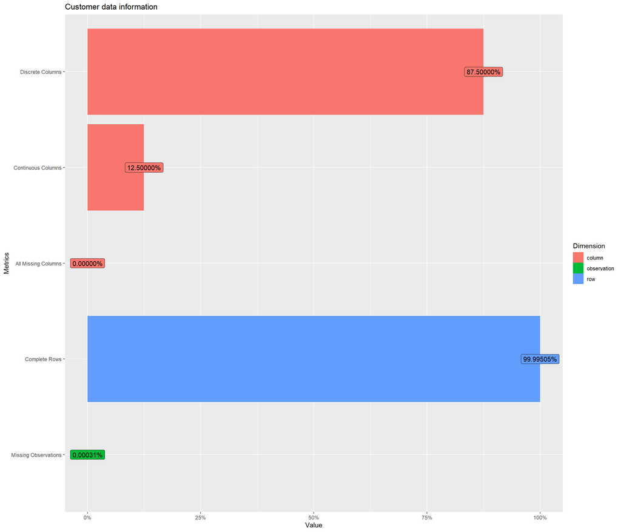

```r
plot_intro(customer, title = "Customer data information")
```

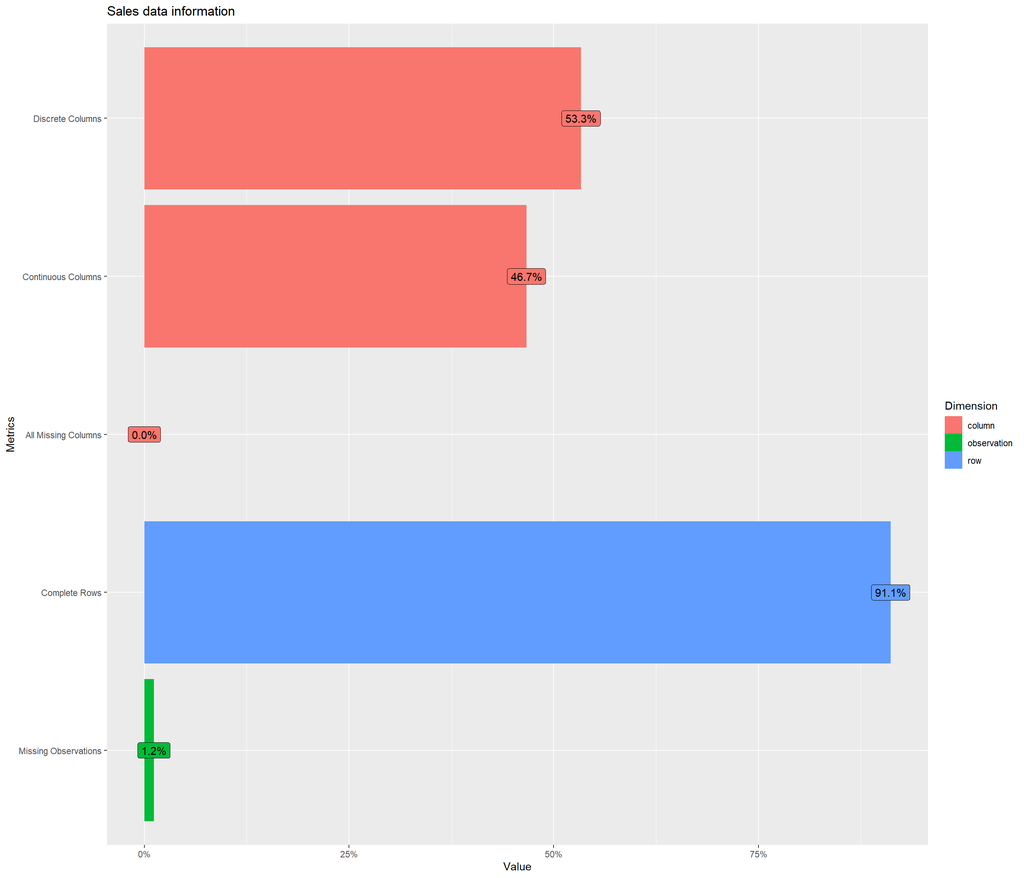

```r
plot_intro(sales, title = "Sales data information")
```

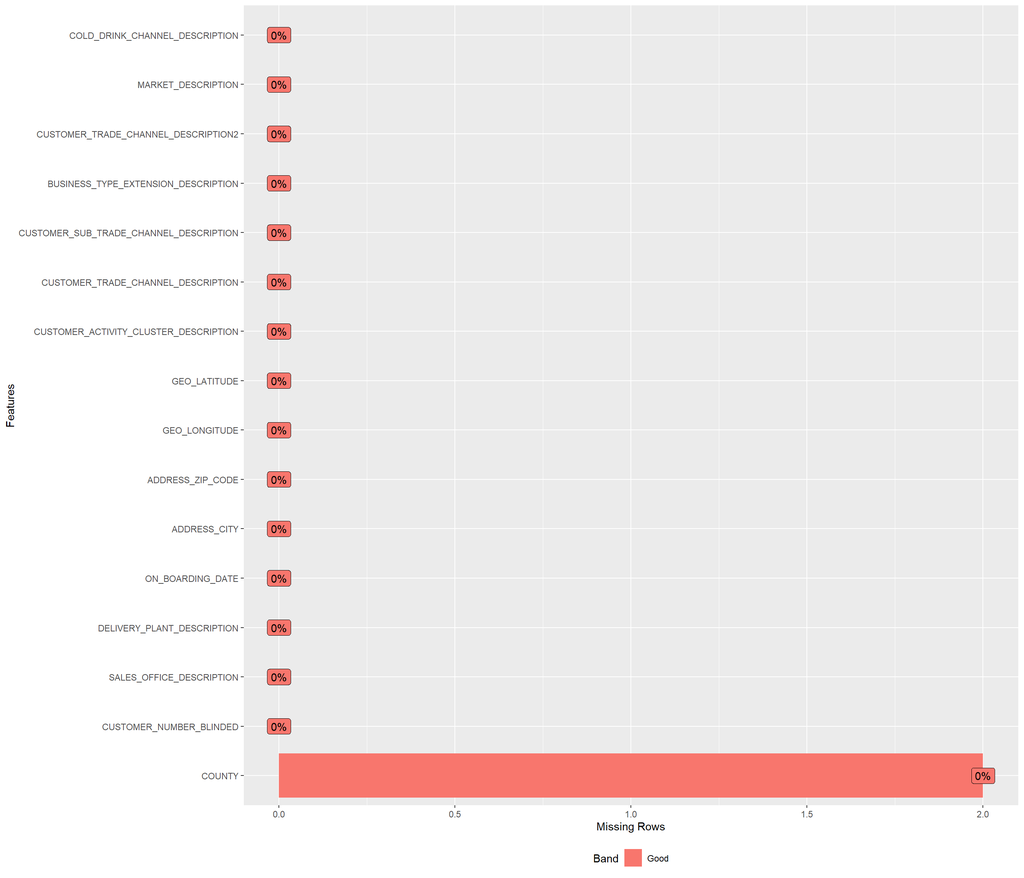

```r
plot_missing(customer)
```

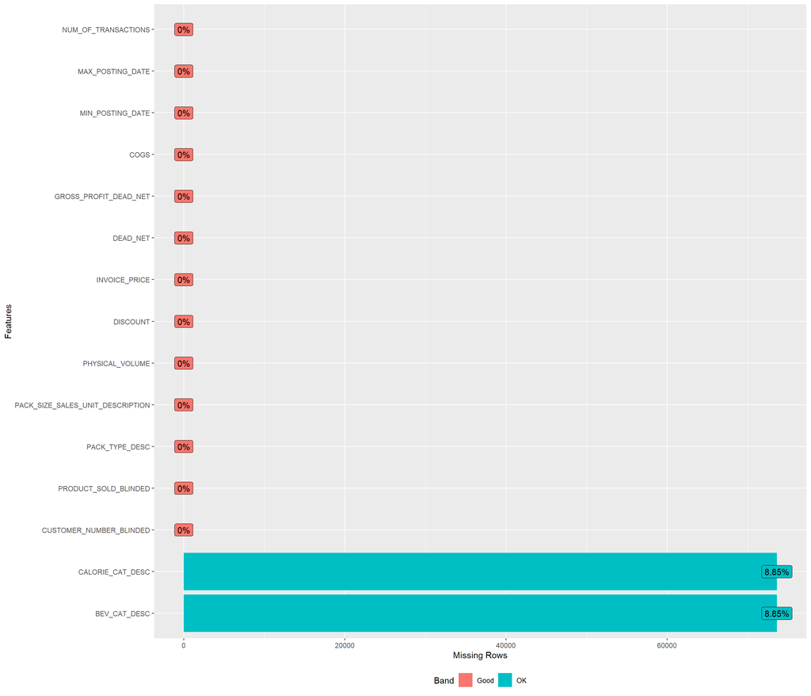

```r
plot_missing(sales)
```

## Distribution of discrete variables with less than 50 categories

```
## 5 columns ignored with more than 50 categories.
## CUSTOMER_NUMBER_BLINDED: 40386 categories
## ON_BOARDING_DATE: 6816 categories
## ADDRESS_CITY: 1361 categories
## ADDRESS_ZIP_CODE: 26046 categories
## COUNTY: 248 categories
```

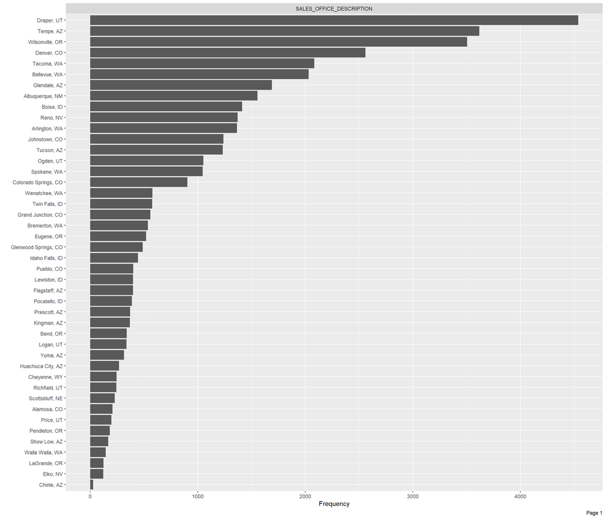

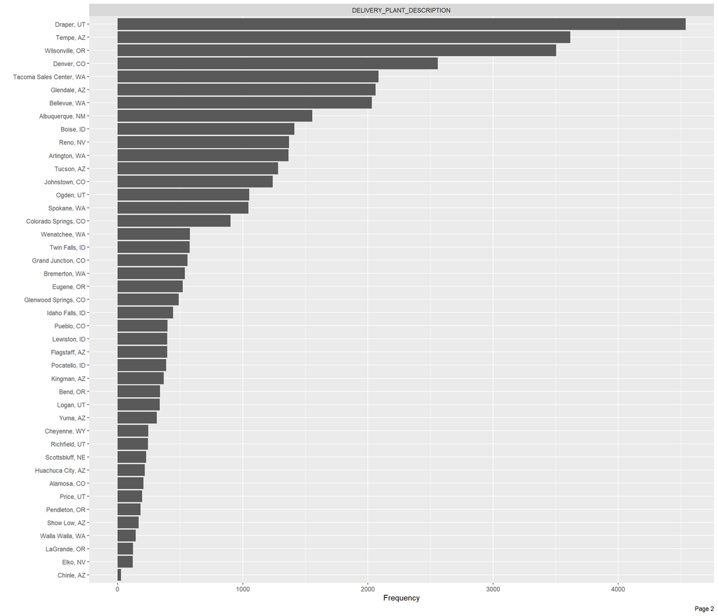

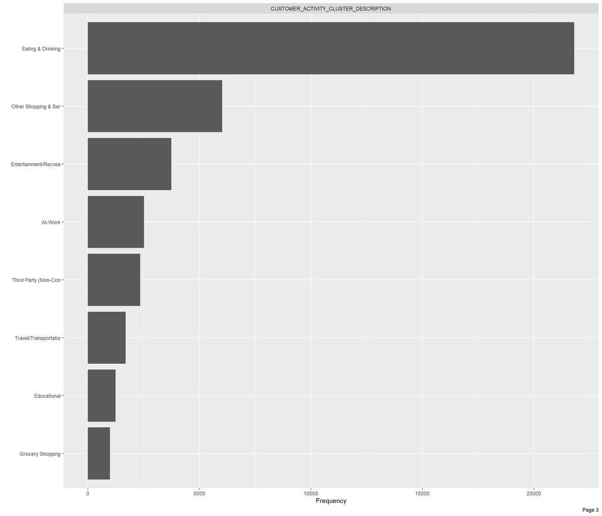

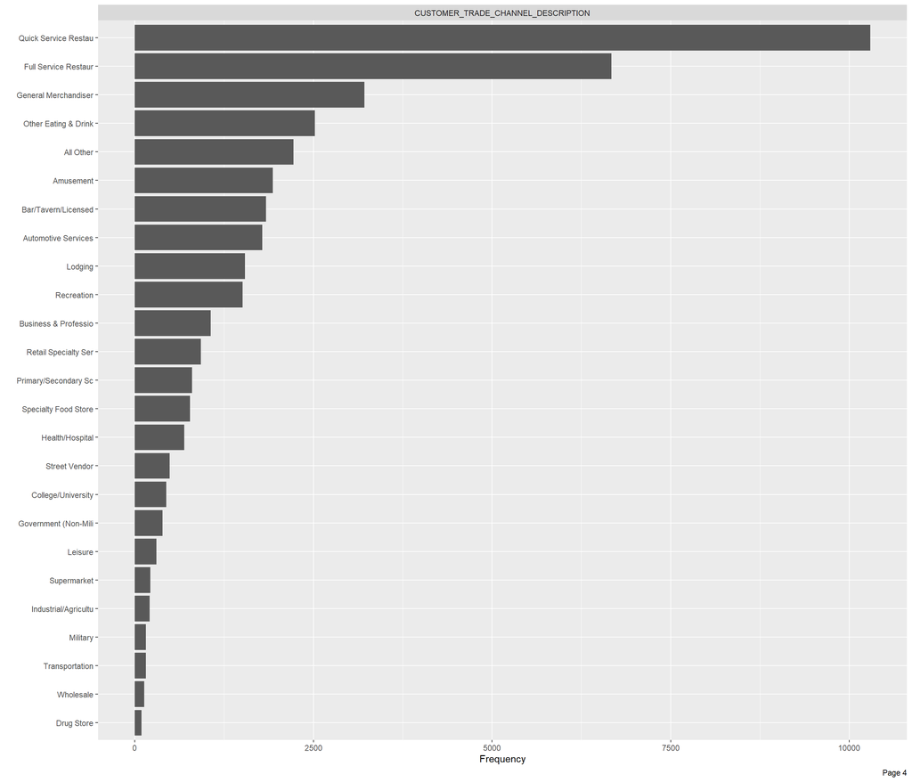

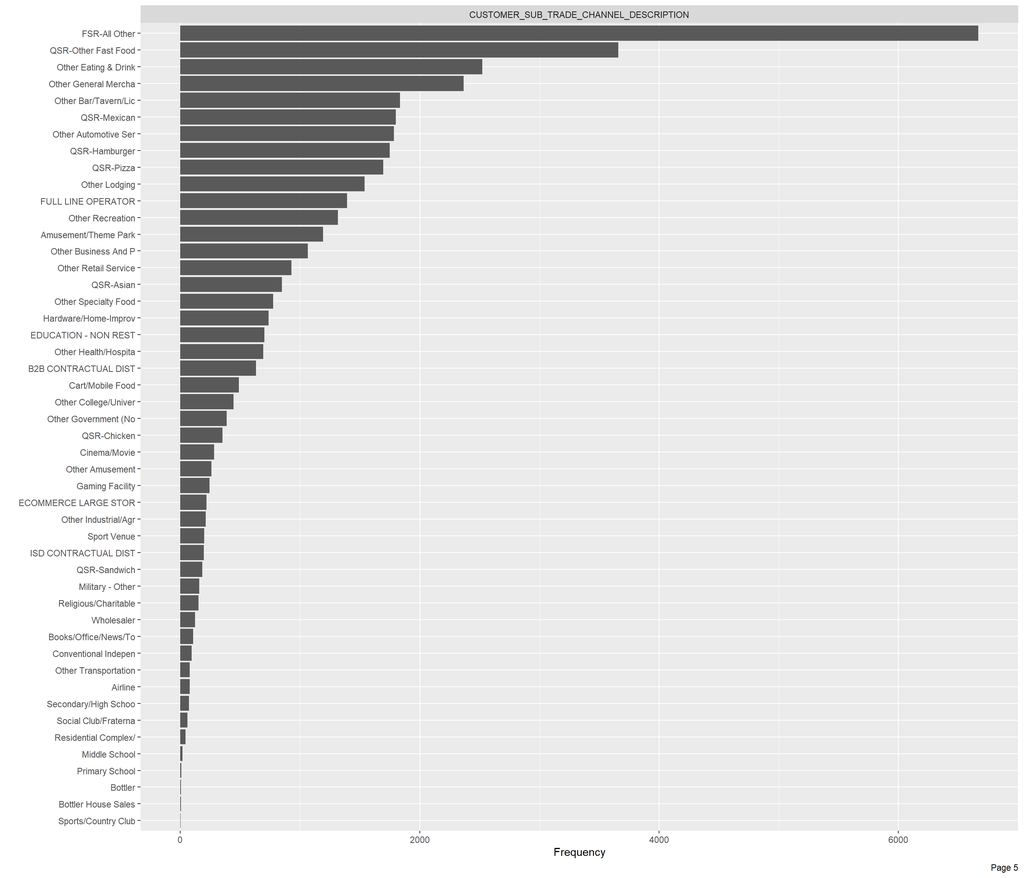

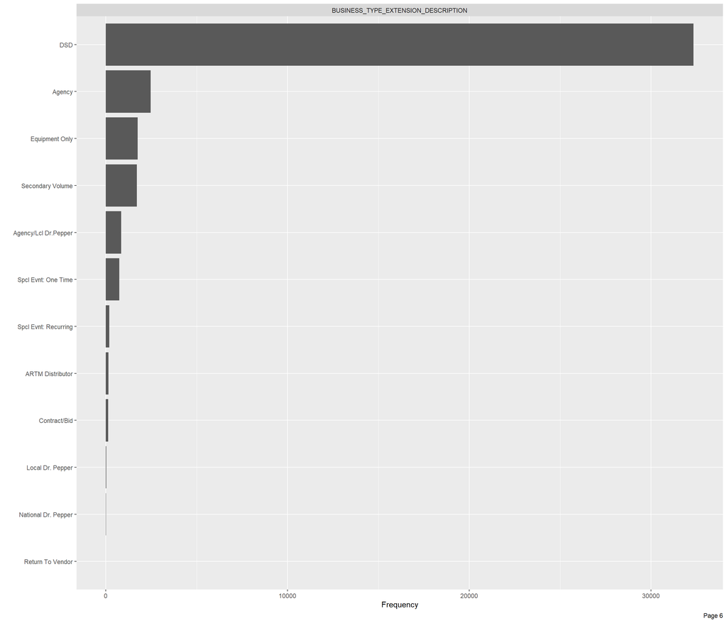

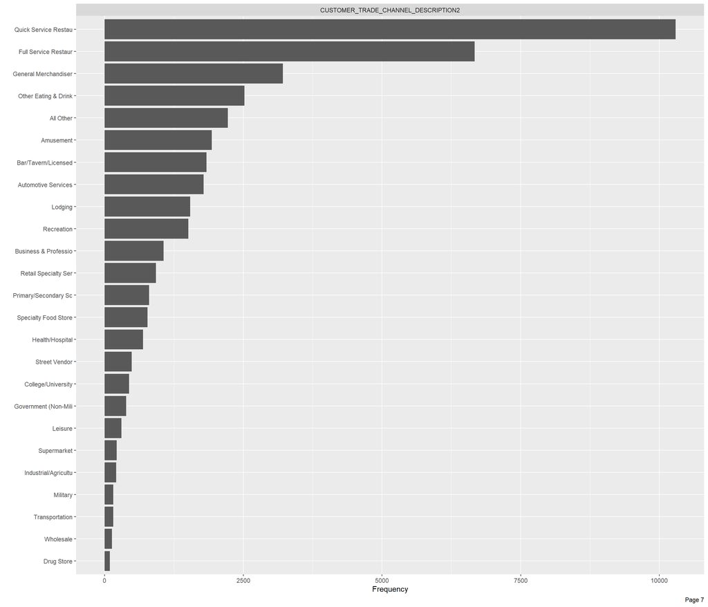

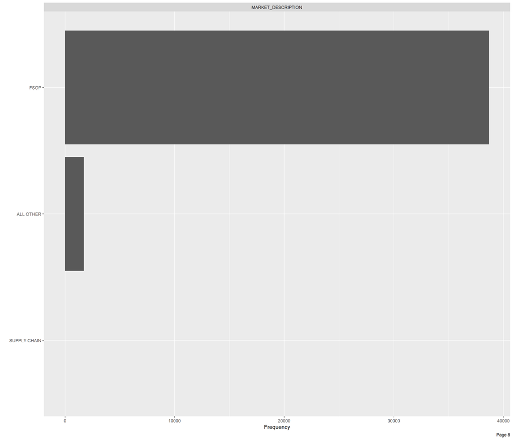

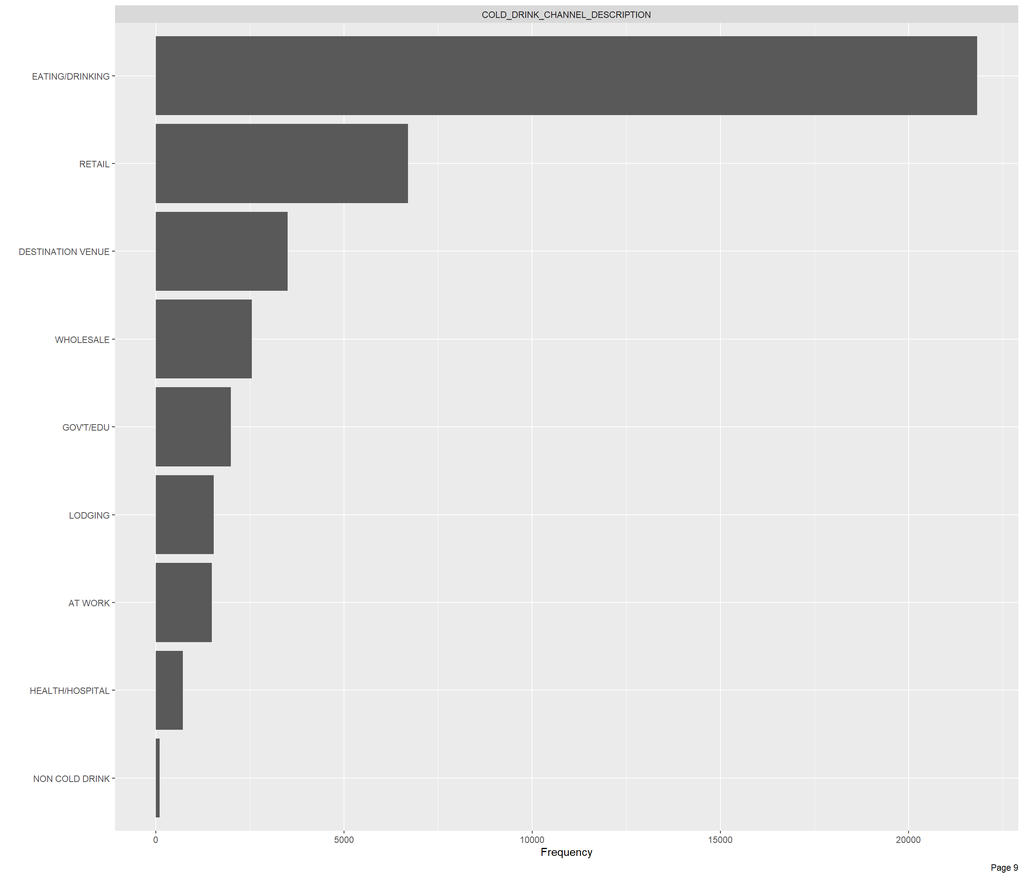

```r
# For customer
plot_bar(customer, nrow = 1, ncol = 1)
```

```
## 5 columns ignored with more than 50 categories.
## CUSTOMER_NUMBER_BLINDED: 40390 categories
## PRODUCT_SOLD_BLINDED: 1558 categories
## PACK_SIZE_SALES_UNIT_DESCRIPTION: 177 categories
## MIN_POSTING_DATE: 718 categories
## MAX_POSTING_DATE: 666 categories
```

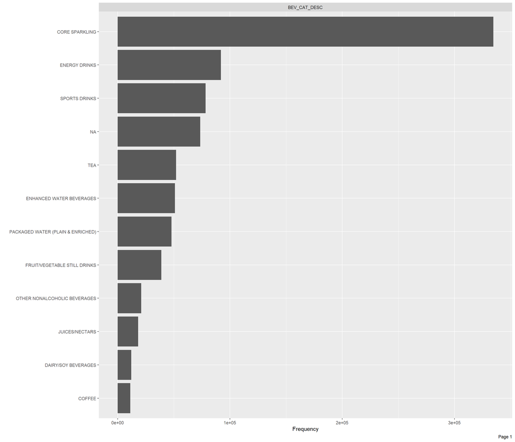

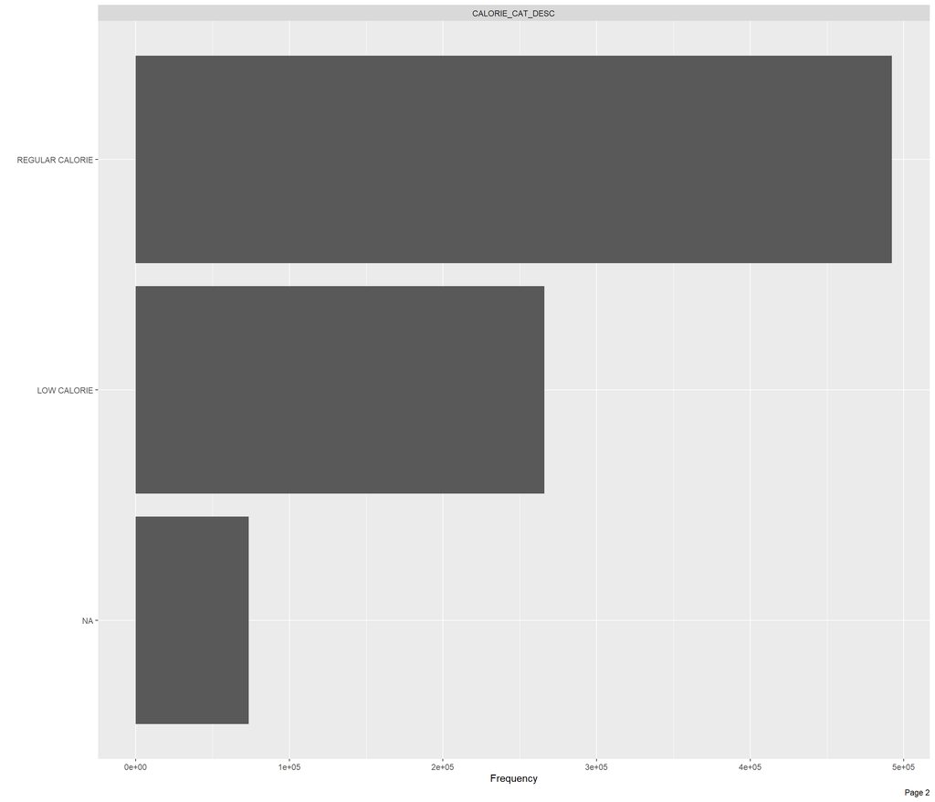

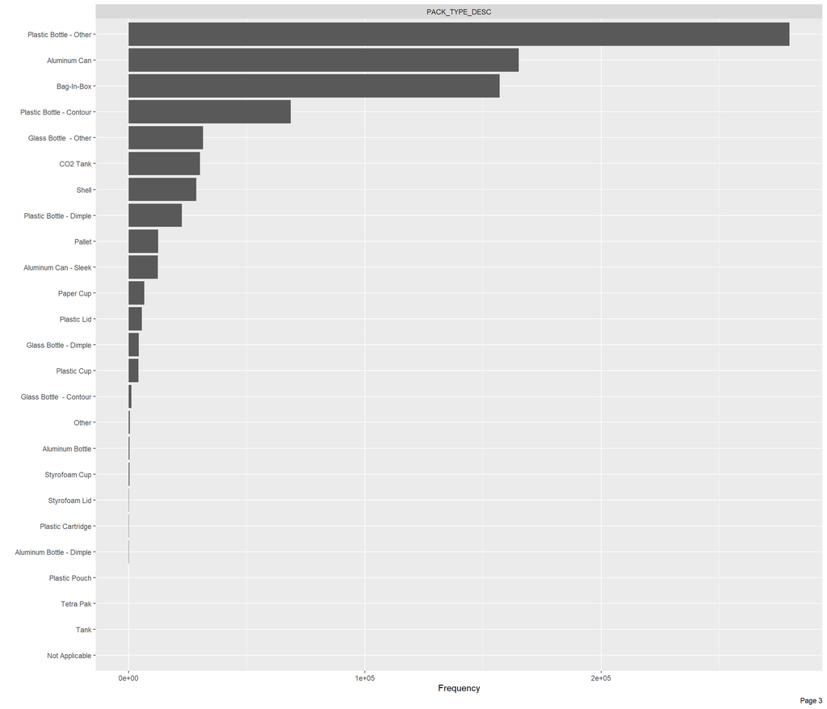

```r
# For sales
plot_bar(sales, nrow = 1, ncol = 1)
```

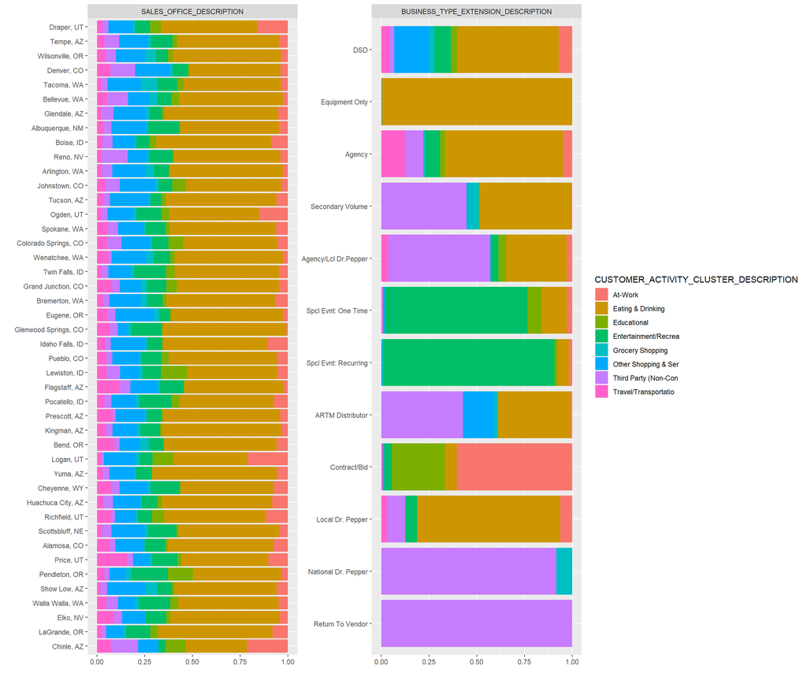

```r
# For customer, showing SALES_OFFICE_DESCRIPTION and BUSINESS_TYPE_EXTENSION_DESCRIPTION broken down by CUSTOMER_ACTIVITY_CLUSTER_DESCRIPTION
plot_bar(customer[,c("SALES_OFFICE_DESCRIPTION","BUSINESS_TYPE_EXTENSION_DESCRIPTION", "CUSTOMER_ACTIVITY_CLUSTER_DESCRIPTION")], nrow = 2, ncol = 2, by = "CUSTOMER_ACTIVITY_CLUSTER_DESCRIPTION")
```

```
## 5 columns ignored with more than 50 categories.
## CUSTOMER_NUMBER_BLINDED: 40390 categories
## PRODUCT_SOLD_BLINDED: 1558 categories
## PACK_SIZE_SALES_UNIT_DESCRIPTION: 177 categories
## MIN_POSTING_DATE: 718 categories
## MAX_POSTING_DATE: 666 categories
```

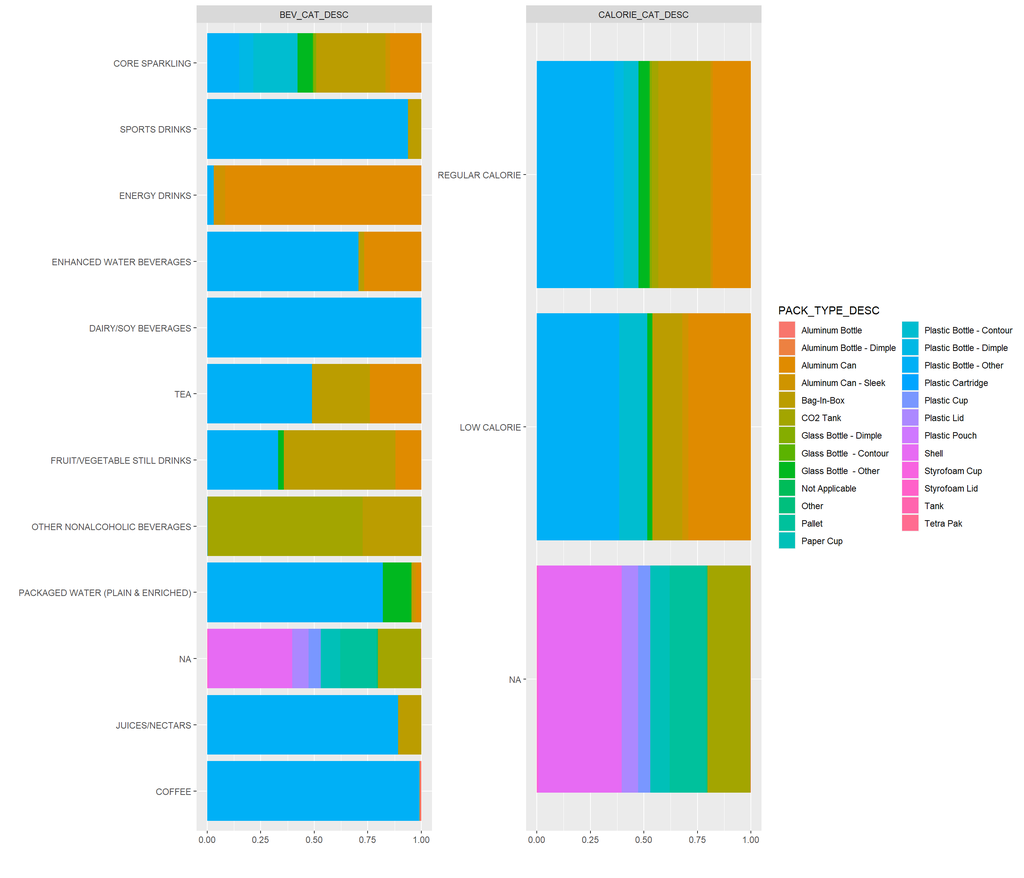

```r
# For Sales, BEV_CAT_DESC and CALORIE_CAT_DESC broken down by PACK_TYPE_DESC
plot_bar(sales, nrow = 2, ncol = 2, by="PACK_TYPE_DESC")
```

## Setting columns as factors

```r
# If a column has 50 or less categories, set it as a factor.
# If it has more than 50 categories, keep it as a character
set_cols_as_factors <- function(df) {
  for (col in names(df)) {
    n_vals <- nlevels(factor(df[[col]]))
    if (n_vals <= 50) {
      df[[col]] <- factor(df[[col]])
    }
  }
  return(df)
}
```

```r
customer <- set_cols_as_factors(customer)
sales <- set_cols_as_factors(sales)
```

## Summary statistics for continuous variables

```r
# Summary statistics for Sales
# Customer has no numerical columns (with the exception of latitude and longitude, which are not continuous variables)
summary(select_if(sales, is.numeric))
```

```
##  PHYSICAL_VOLUME        DISCOUNT         INVOICE_PRICE
##  Min.   :-65832.00   Min.   : -13902.0   Min.   : -22982.4
##  1st Qu.:     1.00   1st Qu.:     17.6   1st Qu.:     31.1
##  Median :     5.00   Median :     90.0   Median :    136.8
##  Mean   :    36.22   Mean   :   1003.8   Mean   :    926.5
##  3rd Qu.:    17.00   3rd Qu.:    413.4   3rd Qu.:    523.4
##  Max.   :136349.00   Max.   :2847661.8   Max.   :1813003.8
##     DEAD_NET         GROSS_PROFIT_DEAD_NET      COGS
##  Min.   : -34534.1   Min.   :-145562.4     Min.   :  -7392.3
##  1st Qu.:     29.3   1st Qu.:      8.6     1st Qu.:     12.5
##  Median :    130.0   Median :     44.8     Median :     72.7
##  Mean   :    845.3   Mean   :    295.0     Mean   :    580.3
##  3rd Qu.:    500.0   3rd Qu.:    181.9     3rd Qu.:    297.7
##  Max.   :1813003.8   Max.   : 883618.1     Max.   :1370468.2
##  NUM_OF_TRANSACTIONS
##  Min.   :  1.00
##  1st Qu.:  2.00
##  Median :  7.00
##  Mean   : 21.23
##  3rd Qu.: 24.00
##  Max.   :468.00
```

```r
# Summary statistics again, but removing negative values (or in this case, setting them to NA)
sales %>%
  select_if(is.numeric) %>%
  mutate_all(~ifelse(. < 0, NA, .)) %>%
  summary()
```

```
##  PHYSICAL_VOLUME        DISCOUNT         INVOICE_PRICE
##  Min.   :     0.00   Min.   :      0.0   Min.   :      0.0
##  1st Qu.:     2.00   1st Qu.:     18.7   1st Qu.:     31.9
##  Median :     6.00   Median :     92.0   Median :    139.4
##  Mean   :    42.84   Mean   :   1009.4   Mean   :    932.3
##  3rd Qu.:    19.00   3rd Qu.:    416.6   3rd Qu.:    528.0
##  Max.   :136349.00   Max.   :2847661.8   Max.   :1813003.8
##  NA's   :53373       NA's   :4199        NA's   :4744
##     DEAD_NET         GROSS_PROFIT_DEAD_NET      COGS
##  Min.   :      0.0   Min.   :     0.0      Min.   :      0.0
##  1st Qu.:     35.3   1st Qu.:    12.5      1st Qu.:     13.2
##  Median :    145.2   Median :    52.6      Median :     74.3
##  Mean   :    879.8   Mean   :   316.2      Mean   :    583.8
##  3rd Qu.:    530.1   3rd Qu.:   198.5      3rd Qu.:    300.7
##  Max.   :1813003.8   Max.   :883618.1      Max.   :1370468.2
##  NA's   :31647       NA's   :46827         NA's   :4697
##  NUM_OF_TRANSACTIONS
##  Min.   :  1.00
##  1st Qu.:  2.00
##  Median :  7.00
##  Mean   : 21.23
##  3rd Qu.: 24.00
##  Max.   :468.00
##
```

## Distribution of order volume

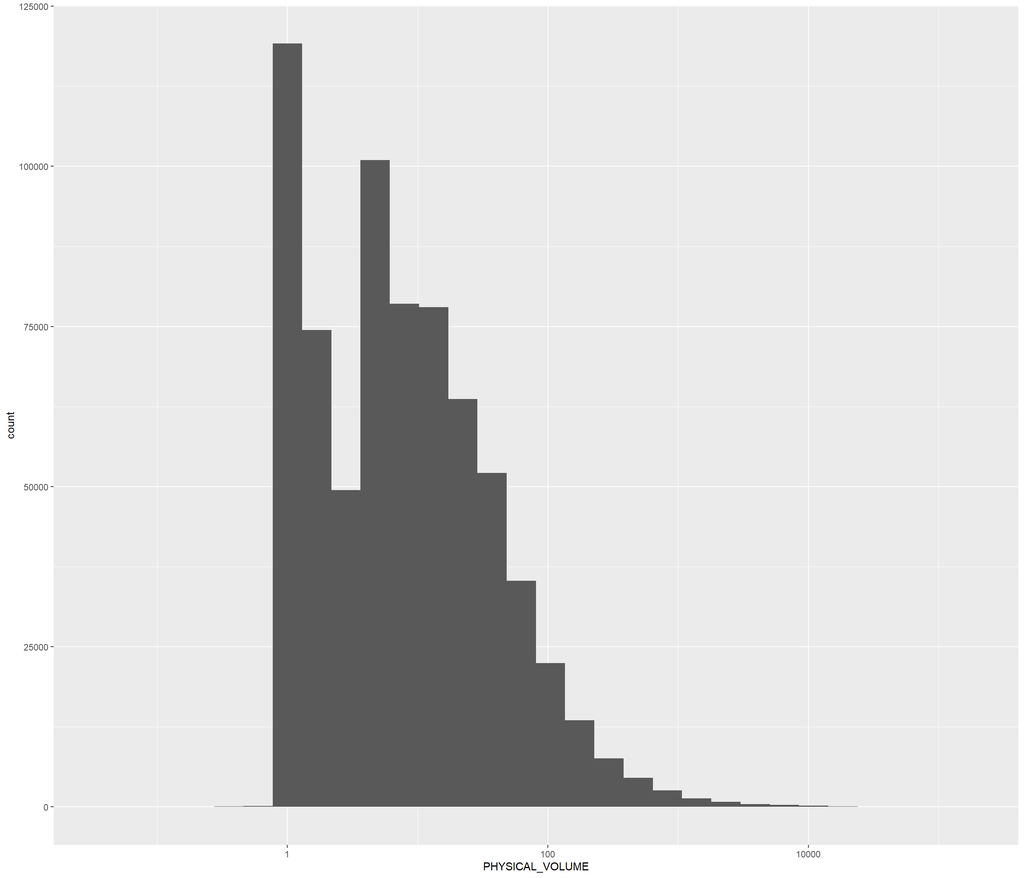

```r
sales %>%
filter(PHYSICAL_VOLUME > 0) %>% # filtering out negative values (returns) and zeroes
  ggplot(aes(PHYSICAL_VOLUME)) +
  geom_histogram() +
  scale_x_log10() # using a log due to skewness in the data
```

## Plotting sales overtime

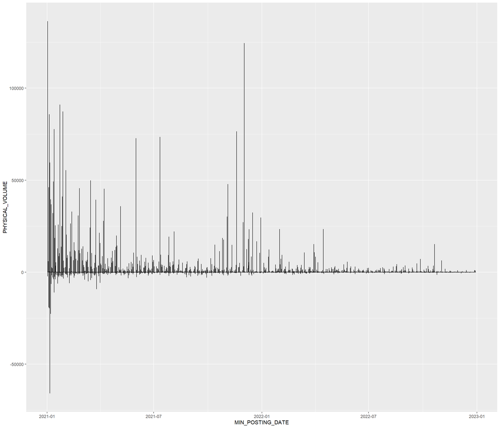

```r
ggplot(sales, aes(x=MIN_POSTING_DATE, y=PHYSICAL_VOLUME)) +
  geom_line()
```

## Customer LTV

> CLTV = (Average Purchase Value x Purchase Frequency x Customer Lifespan)

```r
# Calculating life time in months of a customer
customer$LIFETIME_IN_MONTHS <- floor(as.numeric(difftime(Sys.Date(), customer$ON_BOARDING_DATE, units = "days")) / 30.44)
```

```r
# Joining sales and customer
customer_sales <- inner_join(customer, sales, by = "CUSTOMER_NUMBER_BLINDED")
```

```r
# Creating the LTV table
LTV <- customer_sales %>%
  group_by(CUSTOMER_NUMBER_BLINDED, CUSTOMER_TRADE_CHANNEL_DESCRIPTION) %>%
  summarise(avg_purchase_value = mean(DEAD_NET),
            purchase_frequency = n(),
            lifetime = LIFETIME_IN_MONTHS) %>%
  distinct()
```

[output not shown]

```r
head(LTV)
```

```
## # A tibble: 6 × 5
## # Groups:   CUSTOMER_NUMBER_BLINDED, CUSTOMER_TRADE_CHANNEL_DESCRIPTION [6]
##   CUSTOMER_NUMBER_BLINDED CUSTOMER_TRADE_CHANNEL_DESCR…¹ avg_p…² purch…³ lifet…⁴
##   <chr>                   <fct>                            <dbl>   <int>   <dbl>
## 1 C0001004007230617       All Other                           0        2       3
## 2 C0001004306830869       All Other                           0        6       3
## 3 C0001005009010198       Other Eating & Drink              233.       4      78
## 4 C0001006902500643       Automotive Services               188.      32     117
## 5 C0001007600510372       Bar/Tavern/Licensed               228.      12      33
## 6 C0001009805140924       Full Service Restaur              958.      38     119
## # … with abbreviated variable names ¹CUSTOMER_TRADE_CHANNEL_DESCRIPTION,
## #   ²avg_purchase_value, ³purchase_frequency, ⁴lifetime
```

```r
# CLTV = (Average Purchase Value x Purchase Frequency x Customer Lifespan)
LTV$LTV <- LTV$avg_purchase_value * LTV$purchase_frequency * LTV$lifetime
```

```r
head(LTV)
```

```
## # A tibble: 6 × 6
## # Groups:   CUSTOMER_NUMBER_BLINDED, CUSTOMER_TRADE_CHANNEL_DESCRIPTION [6]
##   CUSTOMER_NUMBER_BLINDED CUSTOMER_TRADE_CHANNE…¹ avg_p…² purch…³ lifet…⁴    LTV
##   <chr>                   <fct>                     <dbl>   <int>   <dbl>  <dbl>
## 1 C0001004007230617       All Other                    0        2       3 0
## 2 C0001004306830869       All Other                    0        6       3 0
## 3 C0001005009010198       Other Eating & Drink       233.       4      78 7.27e4
## 4 C0001006902500643       Automotive Services        188.      32     117 7.03e5
## 5 C0001007600510372       Bar/Tavern/Licensed        228.      12      33 9.04e4
## 6 C0001009805140924       Full Service Restaur       958.      38     119 4.33e6
## # … with abbreviated variable names ¹CUSTOMER_TRADE_CHANNEL_DESCRIPTION,
## #   ²avg_purchase_value, ³purchase_frequency, ⁴lifetime
```

```r
# Total Customer lifetime value
sum(LTV$LTV)
```

```
## [1] 102821324681
```

```r
# LTV by channel
LTV_channel <- LTV %>%
  group_by(CUSTOMER_TRADE_CHANNEL_DESCRIPTION) %>%
  summarise(count = n(),
            total_LTV = sum(LTV)) %>%
  arrange(desc(total_LTV))

LTV_channel %>% gt()
```

| CUSTOMER_TRADE_CHANNEL_DESCRIPTION | count | total_LTV |
| --- | --- | --- |
| All Other | 2221 | 27377143672 |
| Quick Service Restau | 10290 | 11665400472 |
| General Merchandiser | 3213 | 10305852001 |
| Full Service Restaur | 6668 | 7590772742 |
| Amusement | 1933 | 6515699104 |
| Health/Hospital | 694 | 5770597339 |
| Wholesale | 131 | 5396368388 |
| College/University | 444 | 4181391578 |
| Transportation | 158 | 4113990765 |
| Recreation | 1512 | 3666486589 |
| Lodging | 1541 | 3005570876 |
| Leisure | 302 | 2961673271 |
| Other Eating & Drink | 2523 | 2132500545 |
| Automotive Services | 1785 | 1275040246 |
| Supermarket | 218 | 1265027087 |
| Government (Non-Mili | 388 | 1126928893 |
| Bar/Tavern/Licensed | 1837 | 1068221388 |
| Specialty Food Store | 776 | 798054906 |
| Business & Professio | 1066 | 648954048 |
| Primary/Secondary Sc | 803 | 598777887 |
| Military | 159 | 505014918 |
| Retail Specialty Ser | 927 | 412962137 |
| Industrial/Agricultu | 211 | 238552528 |
| Street Vendor | 490 | 128426531 |
| Drug Store | 96 | 71916770 |

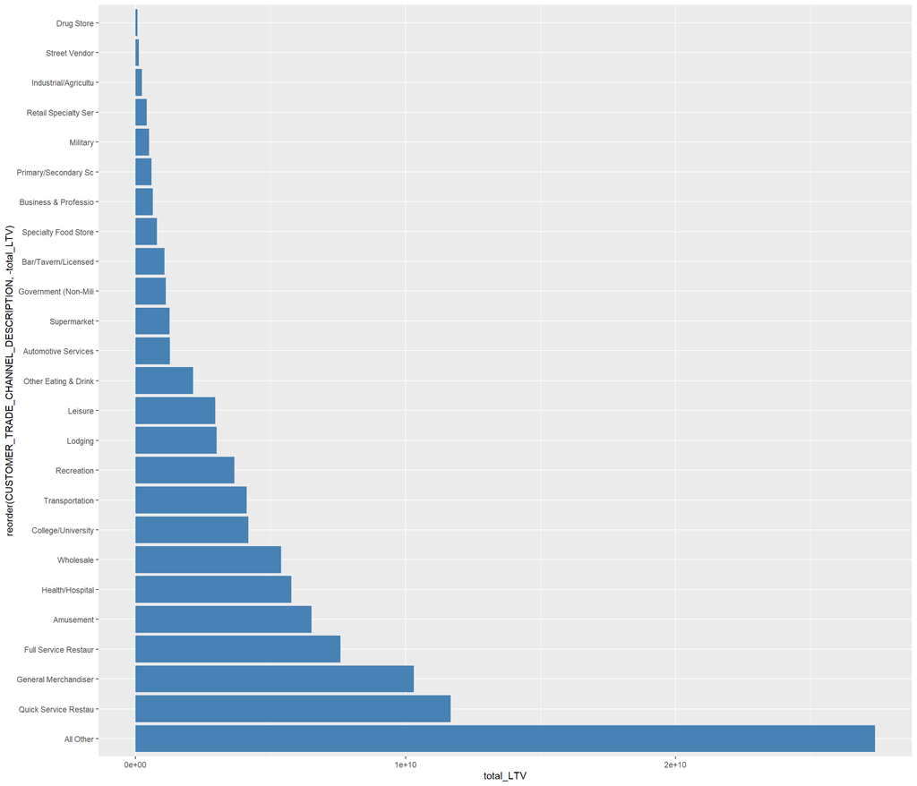

```r
ggplot(LTV_channel,aes(x = reorder(CUSTOMER_TRADE_CHANNEL_DESCRIPTION, -total_LTV), y = total_LTV)) +
  geom_col(fill = "steelblue") +
  coord_flip()
```

# Findings

> What is the distribution of sales for each beverage category?

CORE SPARKING appears to be the most popular category, which I assume pertains to almost all carbonated beverages. I expected ENERGY DRINKS to be popular, but I did not expect it to be the second most popular category.

> What is the distribution of order volume?

> What is the average order value?

The average order value of a non-negative (return) or non-zero transaction is 879.8.

> What packaging types are used the most in each beverage category?

> Which distributions centers generate the most sales?

Draper, UT seems to drive the most sales.

> What is the customer lifetime value?

The overall lifetime value of all customers is 102821324681. The breakdown of lifetime value per customer and by channel is shown above.

> What is the trend of sales over time?

> What kind of businesses do each distribution center work with?